# Project J: The role of attention and inhibition in lingual performance across logographic and alphabetic writing system

Guo

6/12/2019

# Introduction

Word recognition is a higher level of cognitive process that builds on a wide range of human basic cognitive skills. In particular, attention and inhibition may play an important fundamental role in word reading skill.

Studies have shown the comorbidity of ADHD symptoms and reading difficulty (Shanahan et al., 2006; Willcutt et al., 2010; McGrath et al., 2011; Millter et al., 2013; Miranda et al., 2013), both in Chinese and English language systems (Wang et al., 2017; Sexton, Gelhorn, Bell, & Classi, 2012). Specifically, the deficits of visual attention can be associated with poor reading performance (Casco et al., 1998). Futhermore, a 3-year longitudinal study showed that visual spatial attention, i.e., prereading attentional orienting, could predict preschoolers’ future reading skill (Franceschini et al., 2012). In a Chinese reading study, only sustained attention, a basic cognitive skill had effect on future reading performance (Yang X et al., 2019).

Not only attention, but also Ibbotson and Kearvell-White (2015) presented empirical evidence that inhibitory control is a good predictor of grammatical ability, given that individual might need a shared cognitive capacity to cancel an unwanted competition in linguistic performance. Linck et al (2008) also demonstrated that enhanced inhibition control was related to better performance on lexical comprehension and production tasks by bilinguals. In Borella et al’s study (2010), specific inhibition-related functions were found to be related to reading comprehension difficulties. Unskillful readers seemed to be specifically imparied when supression of an active non-target stimuli is needed in the task.

Current study aims to investigate the role of attention and inhibition in reading performance, and the relative contribution of these two executive components in linguistic performance. Furthermore, whether the role and relative contribution of attention and inhibition show differences across two distinctly different language systems, English and Chinese.

## Hypothesis 1. The score of ASRS is a good predictor for the proportion of inhibitions of Go/No-Go task.

```r
head(en_cn_data)
```

```
## # A tibble: 6 x 10
##   ID      gender   age   BMI  ADHD scoreASRS mean_RT_go prop_inhibitions
##   <chr>    <int> <int> <dbl> <int>     <int>      <dbl>            <dbl>
## 1 English      2    33  23.9     5        22       345.            0.5
## 2 English      2    21  18.9     3        18       442.            0.375
## 3 English      1    23  27.4     5        25       319.            0.375
## 4 English      1    19  23.1     0        10       344.            0.875
## 5 English      1    23  25.2     4        20        NA            NA
## 6 English      1    22  23.7     3        19       286.            0.25
## # ... with 2 more variables: correct_mean_RT <dbl>,
## #   correct_prop_total <dbl>
```

```r
lm1 <- lm(prop_inhibitions ~ scoreASRS, data = en_cn_data)
summary(lm1) # p=0.013
```

```
##
## Call:
## lm(formula = prop_inhibitions ~ scoreASRS, data = en_cn_data)
##
## Residuals:
##     Min      1Q  Median      3Q     Max
## -0.6136 -0.1647  0.0677  0.1880  0.4021
##
## Coefficients:
##              Estimate Std. Error t value Pr(>|t|)
## (Intercept)  0.949479   0.098606   9.629   <2e-16 ***
## scoreASRS   -0.014062   0.005628  -2.499   0.0137 *
## ---
## Signif. codes:  0 '***' 0.001 '**' 0.01 '*' 0.05 '.' 0.1 ' ' 1
##
## Residual standard error: 0.2474 on 132 degrees of freedom
##   (92 observations deleted due to missingness)
## Multiple R-squared:  0.04516,    Adjusted R-squared:  0.03793
## F-statistic: 6.243 on 1 and 132 DF,  p-value: 0.01369
```

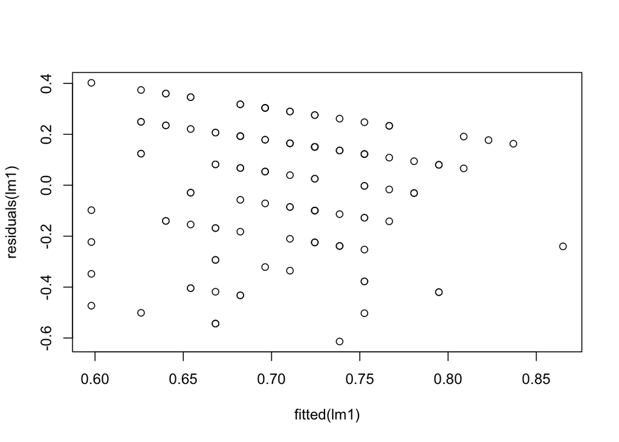

```r
# check asumptions
plot(fitted(lm1), residuals(lm1)) # Linearity
```

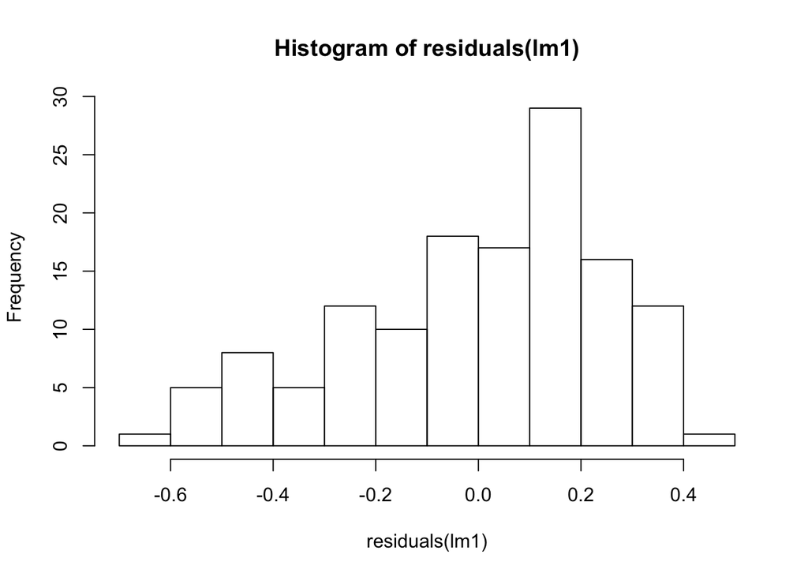

```r
hist(residuals(lm1)) # normality of residuals
```

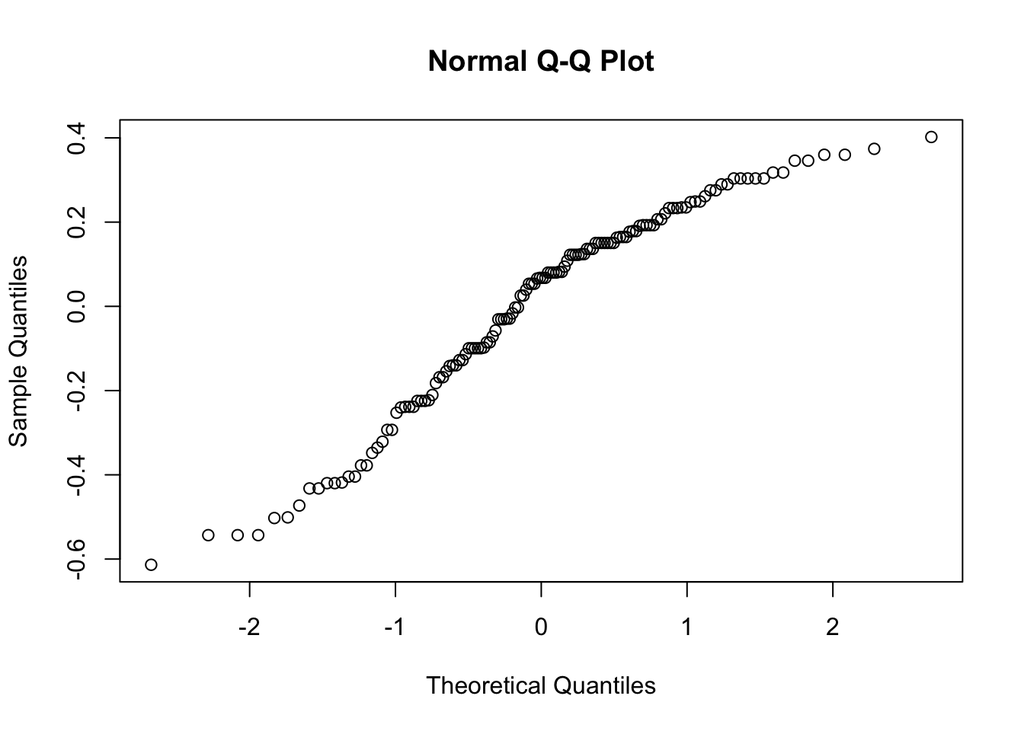

```r
qqnorm(residuals(lm1)) # normality of residuals
```

## Hypothesis 2. BMI is a good predictor for the proportion of inhibitions of Go/No-Go task.

```r
lm2 <- lm(prop_inhibitions ~ BMI, data = en_cn_data)
summary(lm2) #p=0.046
```

```
##
## Call:
## lm(formula = prop_inhibitions ~ BMI, data = en_cn_data)
##
## Residuals:
##      Min       1Q   Median       3Q      Max
## -0.64152 -0.19188  0.06231  0.18834  0.42785
##
## Coefficients:
##              Estimate Std. Error t value Pr(>|t|)
## (Intercept)  0.972786   0.132443   7.345 1.91e-11 ***
## BMI         -0.011948   0.005918  -2.019   0.0455 *
## ---
## Signif. codes:  0 '***' 0.001 '**' 0.01 '*' 0.05 '.' 0.1 ' ' 1
##
## Residual standard error: 0.2494 on 132 degrees of freedom
##   (92 observations deleted due to missingness)
## Multiple R-squared:  0.02995,    Adjusted R-squared:  0.02261
## F-statistic: 4.076 on 1 and 132 DF,  p-value: 0.04552
```

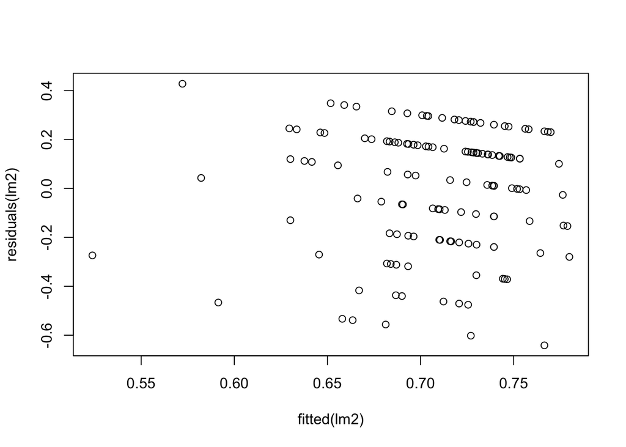

```r
# check asumptions
plot(fitted(lm2), residuals(lm2)) # Linearity
```

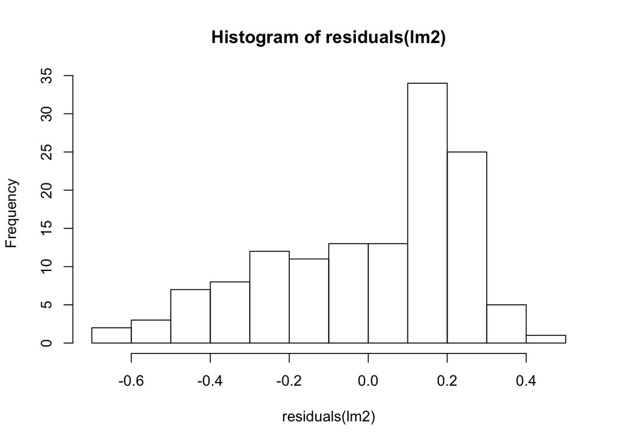

```r
hist(residuals(lm2)) # normality of residuals
```

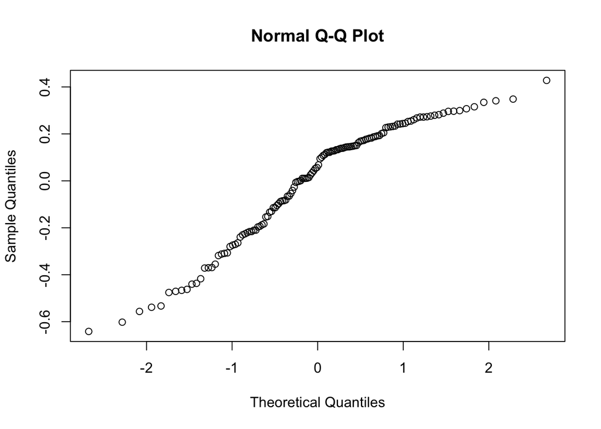

```r
qqnorm(residuals(lm2)) # normality of residuals
```

## Hypothesis 3. Language is a good predictor for the proportion of inhibitions of Go/No-Go task.

```r
lm3 <- lm(prop_inhibitions ~ ID, data = en_cn_data)
summary(lm3) #p=0.6
```

```
##
## Call:
## lm(formula = prop_inhibitions ~ ID, data = en_cn_data)
##
## Residuals:
##      Min       1Q   Median       3Q      Max
## -0.59515 -0.19776  0.05224  0.17724  0.30224
##
## Coefficients:
##             Estimate Std. Error t value Pr(>|t|)
## (Intercept)  0.72015    0.03090  23.305   <2e-16 ***
## IDEnglish   -0.02239    0.04370  -0.512    0.609
## ---
## Signif. codes:  0 '***' 0.001 '**' 0.01 '*' 0.05 '.' 0.1 ' ' 1
##
## Residual standard error: 0.2529 on 132 degrees of freedom
##   (92 observations deleted due to missingness)
## Multiple R-squared:  0.001984,   Adjusted R-squared:  -0.005576
## F-statistic: 0.2625 on 1 and 132 DF,  p-value: 0.6093
```

## Hypothesis 4. Language is a good predictor for the mean reaction time of go stimuli in Go/No-Go task.

```r
lm4 <- lm(mean_RT_go ~ ID, data = en_cn_data)
summary(lm4) #p=0.009
```

```
##
## Call:
## lm(formula = mean_RT_go ~ ID, data = en_cn_data)
##
## Residuals:
##     Min      1Q  Median      3Q     Max
## -201.86  -63.17  -20.77   52.86  463.07
##
## Coefficients:
##             Estimate Std. Error t value Pr(>|t|)
## (Intercept)   438.24      13.04  33.614  < 2e-16 ***
## IDEnglish     -48.53      18.23  -2.663  0.00875 **
## ---
## Signif. codes:  0 '***' 0.001 '**' 0.01 '*' 0.05 '.' 0.1 ' ' 1
##
## Residual standard error: 103.5 on 127 degrees of freedom
##   (97 observations deleted due to missingness)
## Multiple R-squared:  0.05288,    Adjusted R-squared:  0.04542
## F-statistic:  7.09 on 1 and 127 DF,  p-value: 0.008753
```

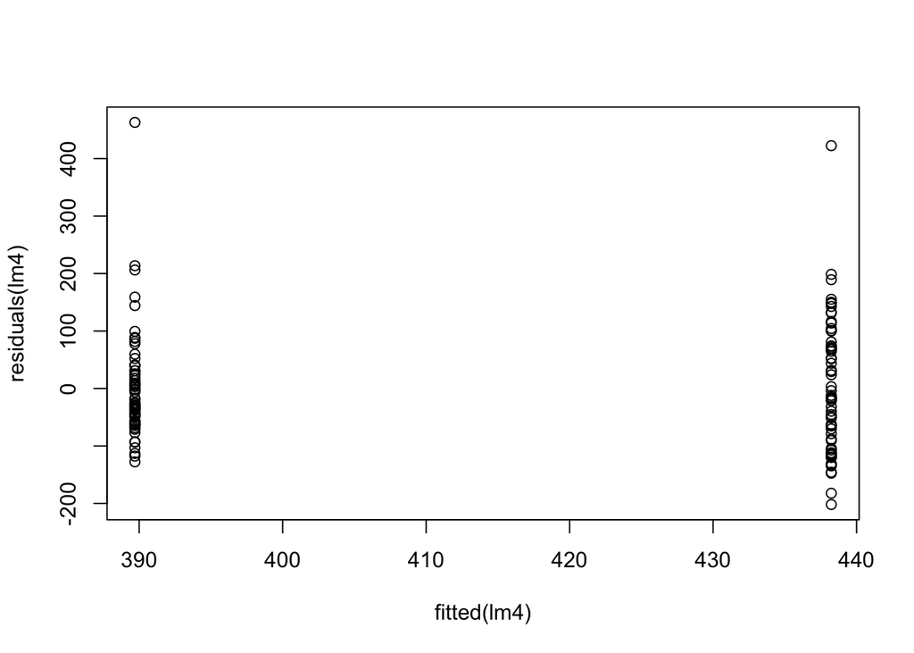

```r
# check asumptions
plot(fitted(lm4), residuals(lm4)) # Linearity
```

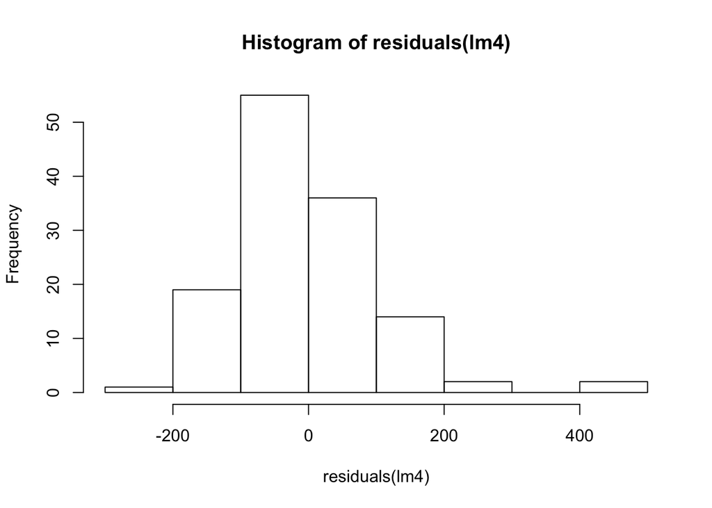

```r
hist(residuals(lm4)) # normality of residuals
```

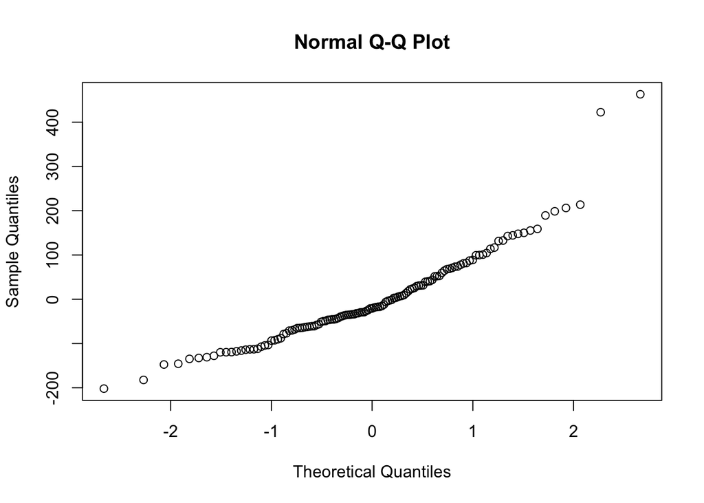

```r
qqnorm(residuals(lm4)) # normality of residuals
```

## Hypothesis 5. Attention and inhibition, measured in GO/No-Go task, have effects on word recognition.

### Test hypothesis 5 in English groups

```
## Data: en_data
## Models:
## lme0: RT ~ 1 + (1 | ID) + (1 | word_pair)
## lme1: RT ~ conditions + (1 | ID) + (1 | word_pair)
##      Df   AIC   BIC logLik deviance  Chisq Chi Df Pr(>Chisq)
## lme0  4 73227 73253 -36610    73219
## lme1  6 73169 73209 -36579    73157 62.005      2  3.434e-14 ***
## ---
## Signif. codes:  0 '***' 0.001 '**' 0.01 '*' 0.05 '.' 0.1 ' ' 1
```

```
## Data: en_data
## Models:
## lme1: RT ~ conditions + (1 | ID) + (1 | word_pair)
## lme2: RT ~ prop_inhibitions + conditions + (1 | ID) + (1 | word_pair)
##      Df   AIC   BIC logLik deviance  Chisq Chi Df Pr(>Chisq)
## lme1  6 73169 73209 -36579    73157
## lme2  7 73171 73217 -36578    73157 0.2419      1     0.6229
```

```
## Data: en_data
## Models:
## lme1: RT ~ conditions + (1 | ID) + (1 | word_pair)
## lme3: RT ~ mean_RT_go + conditions + (1 | ID) + (1 | word_pair)
##      Df   AIC   BIC logLik deviance  Chisq Chi Df Pr(>Chisq)
## lme1  6 73169 73209 -36579    73157
## lme3  7 73168 73214 -36577    73154 3.2948      1     0.0695 .
## ---
## Signif. codes:  0 '***' 0.001 '**' 0.01 '*' 0.05 '.' 0.1 ' ' 1
```

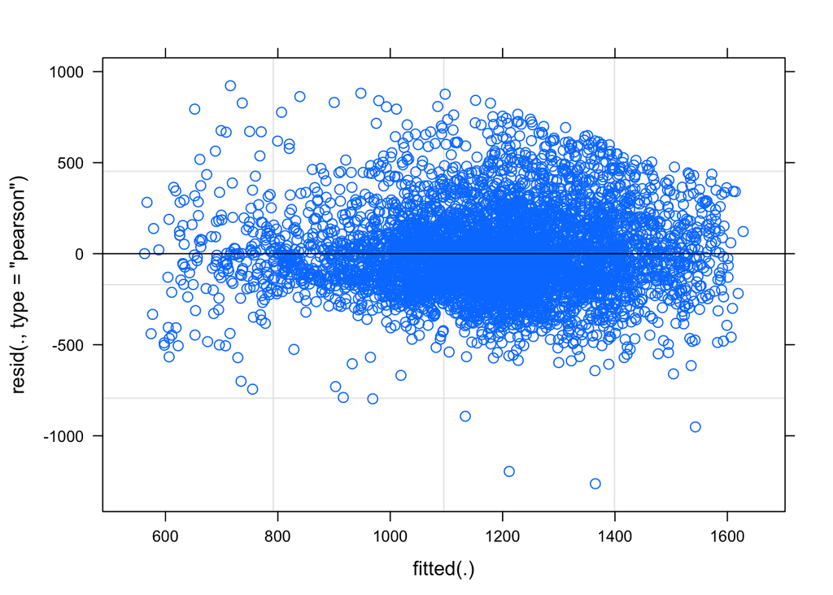

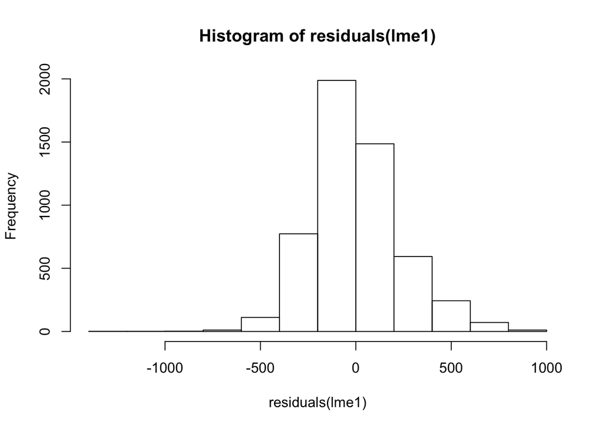

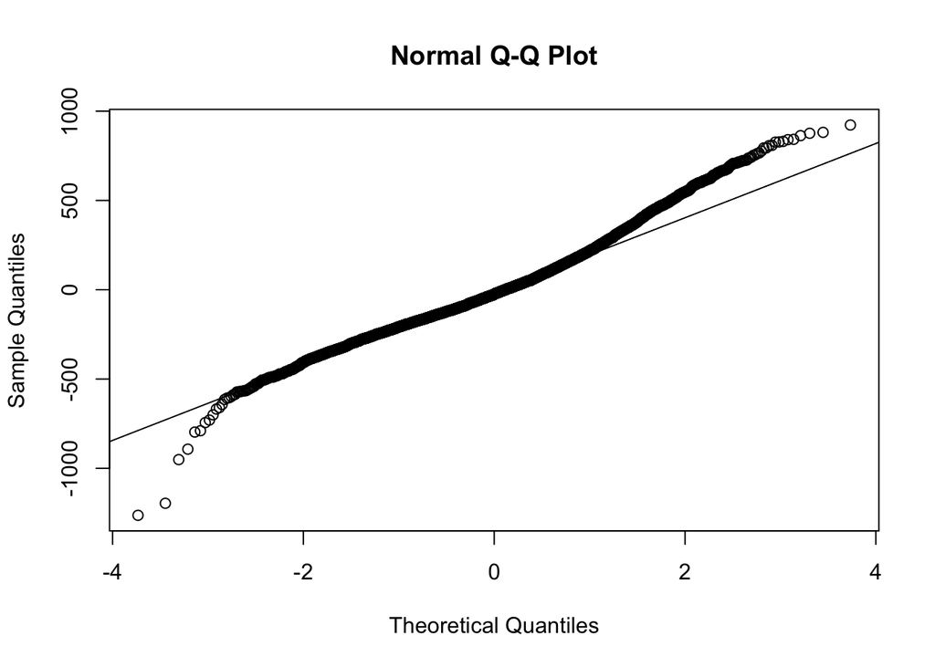

### Test hypothesis 5 in Chinese groups

```
## Data: cn_data
## Models:
## lme0: RT ~ 1 + (1 | ID) + (1 | word_pair)
## lme1: RT ~ conditions + (1 | ID) + (1 | word_pair)
##      Df   AIC   BIC logLik deviance  Chisq Chi Df Pr(>Chisq)
## lme0  4 55469 55495 -27731    55461
## lme1  7 55362 55406 -27674    55348 112.98      3  < 2.2e-16 ***
## ---
## Signif. codes:  0 '***' 0.001 '**' 0.01 '*' 0.05 '.' 0.1 ' ' 1
```

```
## Data: cn_data
## Models:
## lme1: RT ~ conditions + (1 | ID) + (1 | word_pair)
## lme2: RT ~ prop_inhibitions + conditions + (1 | ID) + (1 | word_pair)
##      Df   AIC   BIC logLik deviance  Chisq Chi Df Pr(>Chisq)
## lme1  7 55362 55406 -27674    55348
## lme2  8 55364 55415 -27674    55348 0.0536      1      0.817
```

```
## Data: cn_data
## Models:
## lme1: RT ~ conditions + (1 | ID) + (1 | word_pair)
## lme3: RT ~ mean_RT_go + conditions + (1 | ID) + (1 | word_pair)
##      Df   AIC   BIC logLik deviance  Chisq Chi Df Pr(>Chisq)
## lme1  7 55362 55406 -27674    55348
## lme3  8 55364 55414 -27674    55348 0.6131      1     0.4336
```

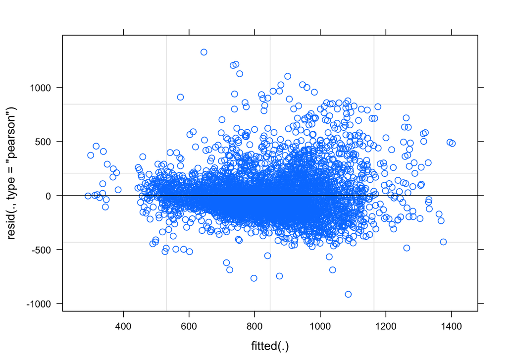

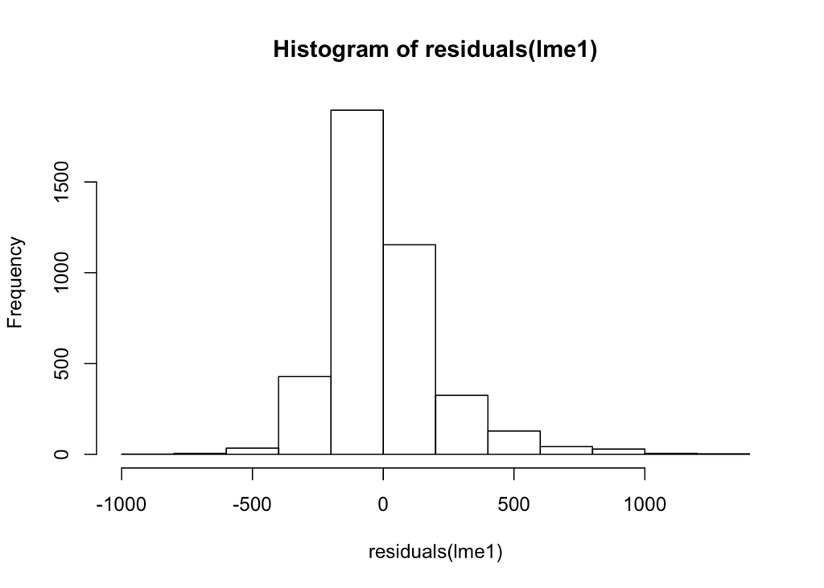

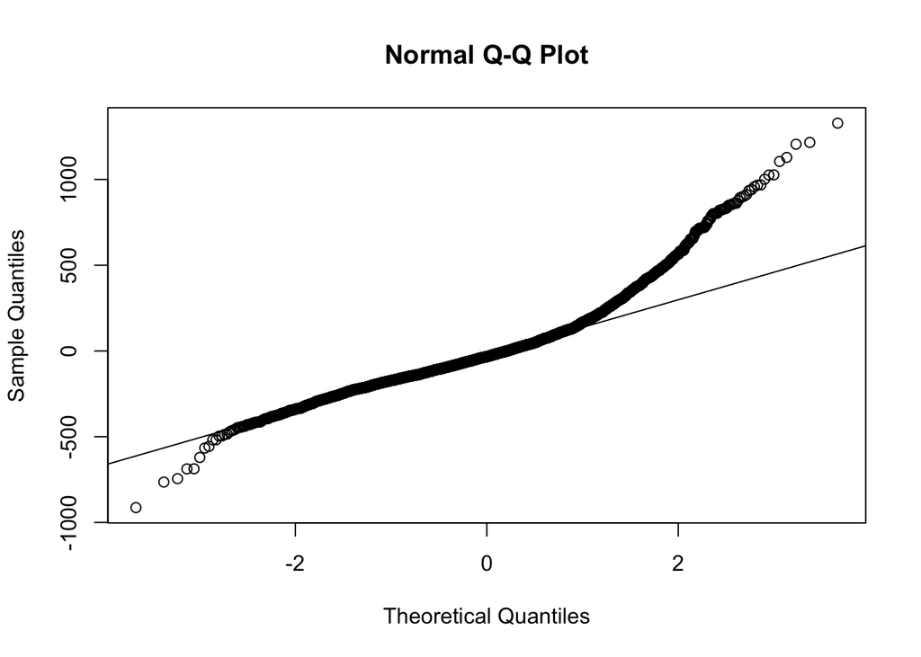